# DATA621_Home_Work_4

Dilip Ganesan

7/5/2018

## Home Work Assignment 4.

## 1.DATA EXPLORATION.(Exploratory Data Analysis EDA)

As first step in our EDA, let us load the train data and do a summary statistics on the loaded dataset.

```r
# Let us load the train.csv data
train = read.csv('insurance_training_data.csv')
test = read.csv('insurance-evaluation-data.csv')

train = within(train, rm('INDEX'))
test = within(test, rm('INDEX'))

summary(train)
```

```
##   TARGET_FLAG       TARGET_AMT        KIDSDRIV           AGE
##  Min.   :0.0000   Min.   :     0   Min.   :0.0000   Min.   :16.00
##  1st Qu.:0.0000   1st Qu.:     0   1st Qu.:0.0000   1st Qu.:39.00
##  Median :0.0000   Median :     0   Median :0.0000   Median :45.00
##  Mean   :0.2638   Mean   :  1504   Mean   :0.1711   Mean   :44.79
##  3rd Qu.:1.0000   3rd Qu.:  1036   3rd Qu.:0.0000   3rd Qu.:51.00
##  Max.   :1.0000   Max.   :107586   Max.   :4.0000   Max.   :81.00
##                                                     NA's   :6
##     HOMEKIDS           YOJ            INCOME     PARENT1
##  Min.   :0.0000   Min.   : 0.0   $0      : 615   No :7084
##  1st Qu.:0.0000   1st Qu.: 9.0           : 445   Yes:1077
##  Median :0.0000   Median :11.0   $26,840 :   4
##  Mean   :0.7212   Mean   :10.5   $48,509 :   4
##  3rd Qu.:1.0000   3rd Qu.:13.0   $61,790 :   4
##  Max.   :5.0000   Max.   :23.0   $107,375:   3
##                   NA's   :454    (Other) :7086
##      HOME_VAL    MSTATUS      SEX               EDUCATION
##  $0      :2294   Yes :4894   M  :3786   <High School :1203
##          : 464   z_No:3267   z_F:4375   Bachelors    :2242
##  $111,129:   3                          Masters      :1658
##  $115,249:   3                          PhD          : 728
##  $123,109:   3                          z_High School:2330
##  $153,061:   3
##  (Other) :5391
##             JOB          TRAVTIME            CAR_USE        BLUEBOOK
##  z_Blue Collar:1825   Min.   :  5.00   Commercial:3029   $1,500 : 157
##  Clerical     :1271   1st Qu.: 22.00   Private   :5132   $6,000 :  34
##  Professional :1117   Median : 33.00                     $5,800 :  33
##  Manager      : 988   Mean   : 33.49                     $6,200 :  33
##  Lawyer       : 835   3rd Qu.: 44.00                     $6,400 :  31
##  Student      : 712   Max.   :142.00                     $5,900 :  30
##  (Other)      :1413                                      (Other):7843
##       TIF                CAR_TYPE    RED_CAR       OLDCLAIM
##  Min.   : 1.000   Minivan    :2145   no :5783   $0     :5009
##  1st Qu.: 1.000   Panel Truck: 676   yes:2378   $1,310 :   4
##  Median : 4.000   Pickup     :1389              $1,391 :   4
##  Mean   : 5.351   Sports Car : 907              $4,263 :   4
##  3rd Qu.: 7.000   Van        : 750              $1,105 :   3
##  Max.   :25.000   z_SUV      :2294              $1,332 :   3
##                                                 (Other):3134
##     CLM_FREQ      REVOKED       MVR_PTS          CAR_AGE
##  Min.   :0.0000   No :7161   Min.   : 0.000   Min.   :-3.000
##  1st Qu.:0.0000   Yes:1000   1st Qu.: 0.000   1st Qu.: 1.000
##  Median :0.0000              Median : 1.000   Median : 8.000
##  Mean   :0.7986              Mean   : 1.696   Mean   : 8.328
##  3rd Qu.:2.0000              3rd Qu.: 3.000   3rd Qu.:12.000
##  Max.   :5.0000              Max.   :13.000   Max.   :28.000
##                                               NA's   :510
##                  URBANICITY
##  Highly Urban/ Urban  :6492
##  z_Highly Rural/ Rural:1669
##
##
##
##
##
```

We will make sure there is no inappropriate distribution of target(response) variables in our training data.

```r
knitr::kable(table(train$TARGET_FLAG))
```

| Var1 | Freq |
| --- | --- |
| 0 | 6008 |
| 1 | 2153 |

## Examination of Data Set.

1. There are 8161 rows and 25 columns(excluding the INDEX) in the train data set. The 2 columns are response variable and rest are predictor variables.

TARGET_FLAG is a binary variable where 1 means that person had a crash. 0 means that person did not had the crash.

TARGET_AMT is the expense because of the accident. 0 when there is no accident.

## Statistical Summary of Data Set:

```r
summary = describe(train, quant = c(.25,.75))
knitr::kable(summary)
```

|  | vars | n | mean | sd | median | trimmed | mad | min | max | range | skew | kurtosis | se | Q0.25 | Q0.75 |
| --- | --- | --- | --- | --- | --- | --- | --- | --- | --- | --- | --- | --- | --- | --- | --- |
| TARGET_FLAG | 1 | 8161 | 0.2638157 | 0.4407276 | 0 | 0.2047787 | 0.0000 | 0 | 1.0 | 1.0 | 1.0716614 | -0.8516462 | 0.0048786 | 0 | 1 |
| TARGET_AMT | 2 | 8161 | 1504.3246481 | 4704.0269298 | 0 | 593.7121106 | 0.0000 | 0 | 107586.1 | 107586.1 | 8.7063034 | 112.2884386 | 52.0712628 | 0 | 1036 |
| KIDSDRIV | 3 | 8161 | 0.1710575 | 0.5115341 | 0 | 0.0252719 | 0.0000 | 0 | 4.0 | 4.0 | 3.3518374 | 11.7801916 | 0.0056624 | 0 | 0 |
| AGE | 4 | 8155 | 44.7903127 | 8.6275895 | 45 | 44.8306513 | 8.8956 | 16 | 81.0 | 65.0 | -0.0289889 | -0.0617020 | 0.0955383 | 39 | 51 |
| HOMEKIDS | 5 | 8161 | 0.7212351 | 1.1163233 | 0 | 0.4971665 | 0.0000 | 0 | 5.0 | 5.0 | 1.3411271 | 0.6489915 | 0.0123571 | 0 | 1 |
| YOJ | 6 | 7707 | 10.4992864 | 4.0924742 | 11 | 11.0711853 | 2.9652 | 0 | 23.0 | 23.0 | -1.2029676 | 1.1773410 | 0.0466169 | 9 | 13 |
| INCOME* | 7 | 8161 | 2875.5505453 | 2090.6786785 | 2817 | 2816.9534385 | 2799.1488 | 1 | 6613.0 | 6612.0 | 0.1094699 | -1.2853032 | 23.1427840 | 926 | 4701 |
| PARENT1* | 8 | 8161 | 1.1319691 | 0.3384779 | 1 | 1.0399755 | 0.0000 | 1 | 2.0 | 1.0 | 2.1743561 | 2.7281589 | 0.0037468 | 1 | 1 |
| HOME_VAL* | 9 | 8161 | 1684.8931503 | 1697.3791897 | 1245 | 1516.4994639 | 1842.8718 | 1 | 5107.0 | 5106.0 | 0.5162324 | -1.1810965 | 18.7891522 | 2 | 3164 |
| MSTATUS* | 10 | 8161 | 1.4003186 | 0.4899929 | 1 | 1.3754021 | 0.0000 | 1 | 2.0 | 1.0 | 0.4068189 | -1.8347231 | 0.0054240 | 1 | 2 |
| SEX* | 11 | 8161 | 1.5360863 | 0.4987266 | 2 | 1.5451064 | 0.0000 | 1 | 2.0 | 1.0 | -0.1446959 | -1.9793056 | 0.0055207 | 1 | 2 |
| EDUCATION* | 12 | 8161 | 3.0906752 | 1.4448565 | 3 | 3.1133405 | 1.4826 | 1 | 5.0 | 4.0 | 0.1162654 | -1.3799674 | 0.0159939 | 2 | 5 |
| JOB* | 13 | 8161 | 5.6871707 | 2.6818733 | 6 | 5.8145198 | 2.9652 | 1 | 9.0 | 8.0 | -0.3067029 | -1.2222635 | 0.0296870 | 3 | 8 |
| TRAVTIME | 14 | 8161 | 33.4857248 | 15.9083334 | 33 | 32.9954051 | 16.3086 | 5 | 142.0 | 137.0 | 0.4468174 | 0.6643331 | 0.1760974 | 22 | 44 |
| CAR_USE* | 15 | 8161 | 1.6288445 | 0.4831436 | 2 | 1.6610507 | 0.0000 | 1 | 2.0 | 1.0 | -0.5332937 | -1.7158080 | 0.0053482 | 1 | 2 |
| BLUEBOOK* | 16 | 8161 | 1283.6185516 | 893.5117428 | 1124 | 1259.5665492 | 1132.7064 | 1 | 2789.0 | 2788.0 | 0.2472837 | -1.3624655 | 9.8907352 | 478 | 2234 |
| TIF | 17 | 8161 | 5.3513050 | 4.1466353 | 4 | 4.8402512 | 4.4478 | 1 | 25.0 | 24.0 | 0.8908120 | 0.4224940 | 0.0459012 | 1 | 7 |
| CAR_TYPE* | 18 | 8161 | 3.5297145 | 1.9653570 | 3 | 3.5371420 | 2.9652 | 1 | 6.0 | 5.0 | -0.0047181 | -1.5165329 | 0.0217555 | 1 | 6 |
| RED_CAR* | 19 | 8161 | 1.2913859 | 0.4544287 | 1 | 1.2392403 | 0.0000 | 1 | 2.0 | 1.0 | 0.9180255 | -1.1573709 | 0.0050303 | 1 | 2 |
| OLDCLAIM* | 20 | 8161 | 552.2714128 | 862.2006829 | 1 | 380.3196508 | 0.0000 | 1 | 2857.0 | 2856.0 | 1.3085876 | 0.2461666 | 9.5441372 | 1 | 1015 |
| CLM_FREQ | 21 | 8161 | 0.7985541 | 1.1584527 | 0 | 0.5886047 | 0.0000 | 0 | 5.0 | 5.0 | 1.2087985 | 0.2842890 | 0.0128235 | 0 | 2 |
| REVOKED* | 22 | 8161 | 1.1225340 | 0.3279216 | 1 | 1.0281820 | 0.0000 | 1 | 2.0 | 1.0 | 2.3018899 | 3.2991013 | 0.0036299 | 1 | 1 |
| MVR_PTS | 23 | 8161 | 1.6955030 | 2.1471117 | 1 | 1.3138306 | 1.4826 | 0 | 13.0 | 13.0 | 1.3478403 | 1.3754900 | 0.0237675 | 0 | 3 |
| CAR_AGE | 24 | 7651 | 8.3283231 | 5.7007424 | 8 | 7.9632413 | 7.4130 | -3 | 28.0 | 31.0 | 0.2819531 | -0.7489756 | 0.0651737 | 1 | 12 |
| URBANICITY* | 25 | 8161 | 1.2045093 | 0.4033673 | 1 | 1.1306479 | 0.0000 | 1 | 2.0 | 1.0 | 1.4649406 | 0.1460688 | 0.0044651 | 1 | 1 |

1. CAR_AGE, YOJ and AGE has NA values.
2. CAR_AGE min value is -3. This needs some manipulation.
3. TARGET_AMT has a large skewness. We need to do some transformation on this variable.

## Visual Exploration of Data set:

*Histogram*

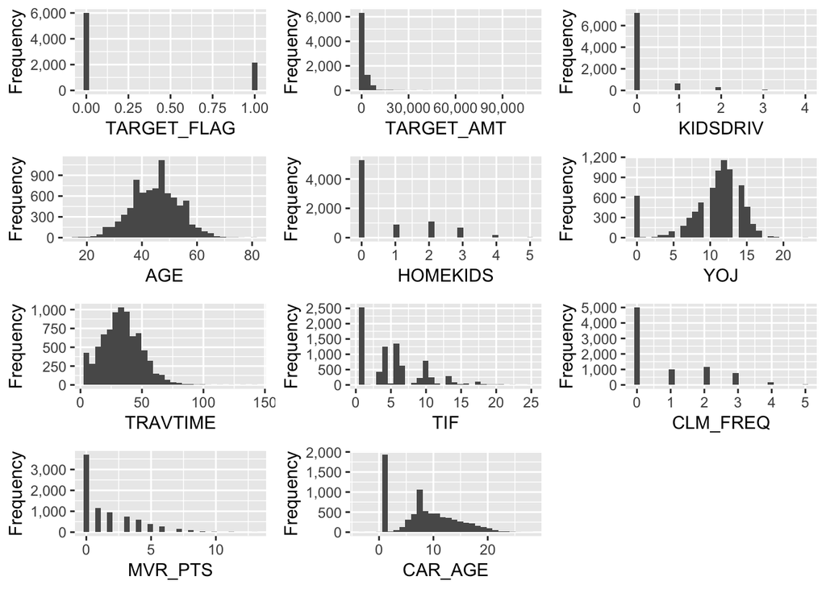

```r
ggtrain = split_columns(train)

plot_histogram(ggtrain$continuous)
```

```
## 4 columns ignored with more than 50 categories.
## INCOME: 6613 categories
## HOME_VAL: 5107 categories
## BLUEBOOK: 2789 categories
## OLDCLAIM: 2857 categories
```

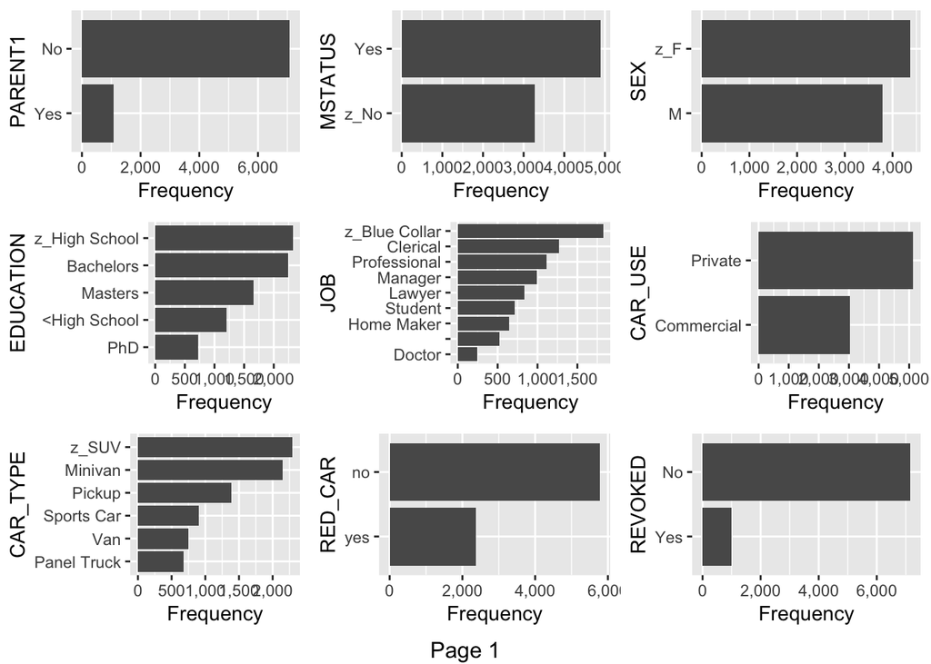

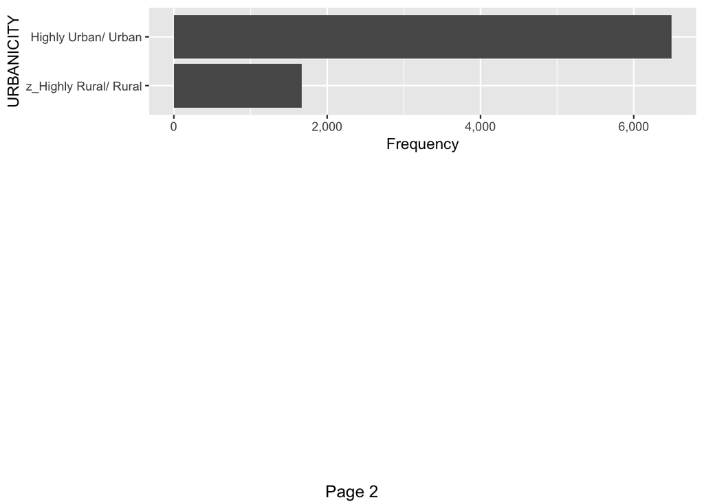

```r
plot_bar(ggtrain$discrete)
```

1. From the histogram we can see that variable TARGET_AMT is skewed. This is a ideal candidate for transformation.
2. We can see TARGET_FLAG has more observations of not having accidents compared to having an accidents.

*ScatterPlot*

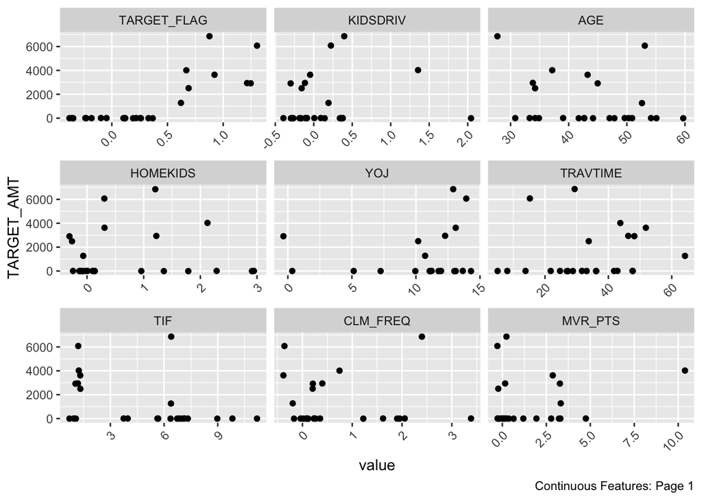

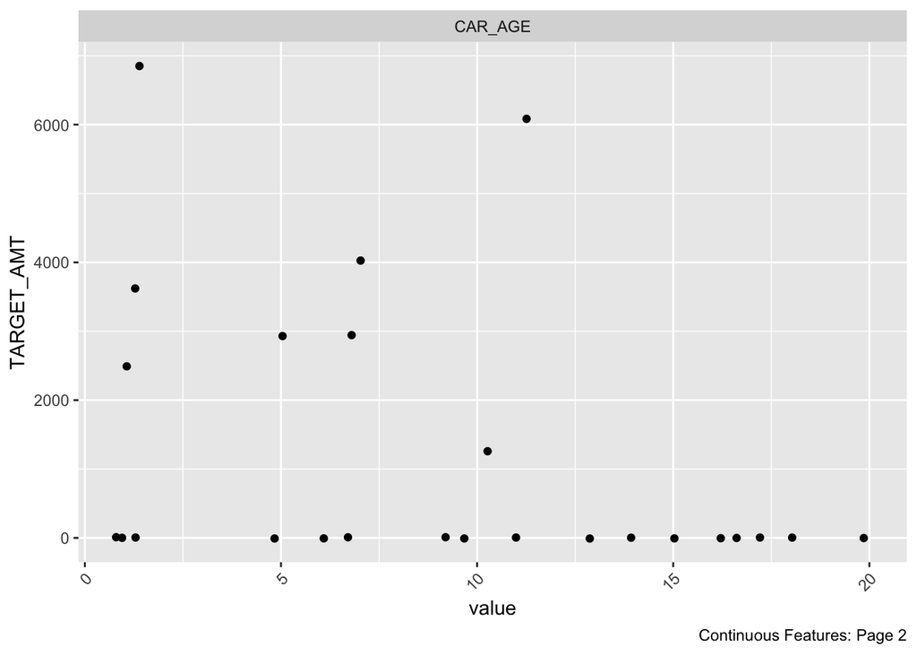

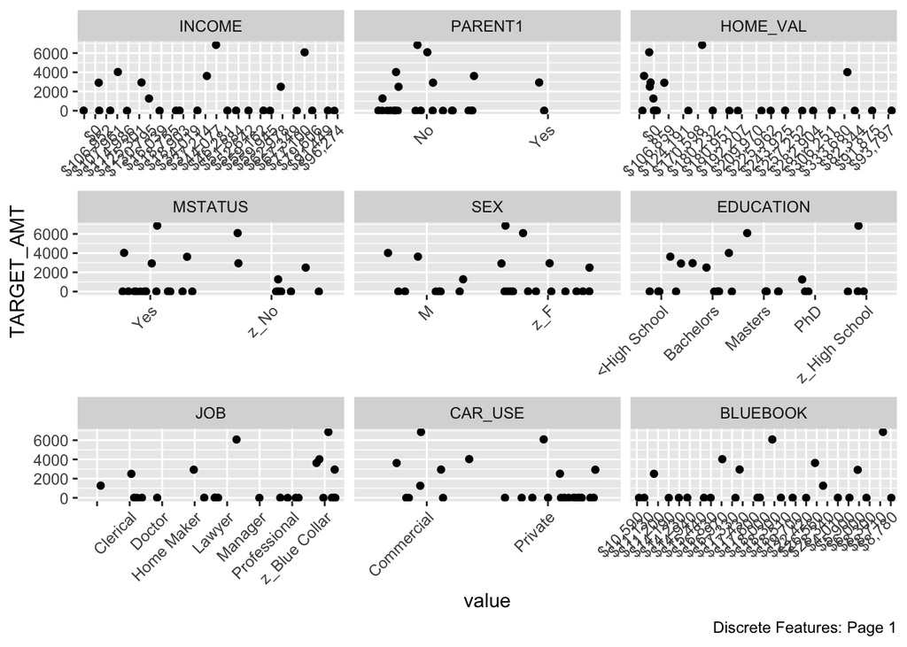

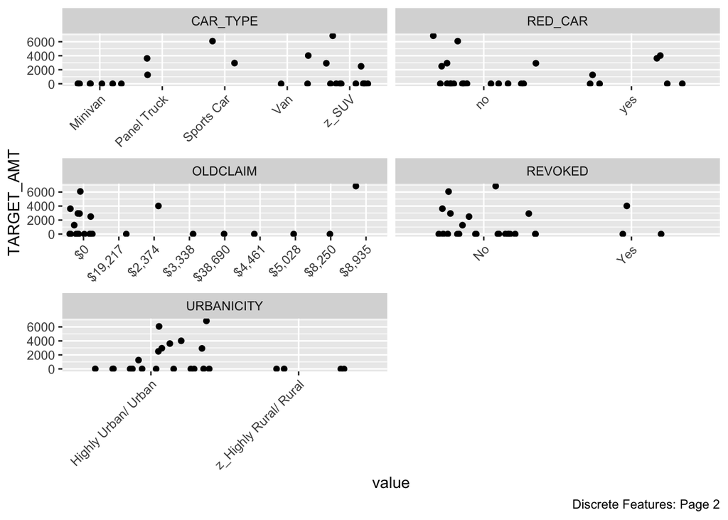

```r
plot_scatterplot(train[1:25,], "TARGET_AMT", position = "jitter")
```

On the analysis of Scatter plot between TARGET_AMT and other Predictor variables, we do not see any pronounced positive or negative relationship.

*MultiCollinearity between predictor variables and also with response variables*

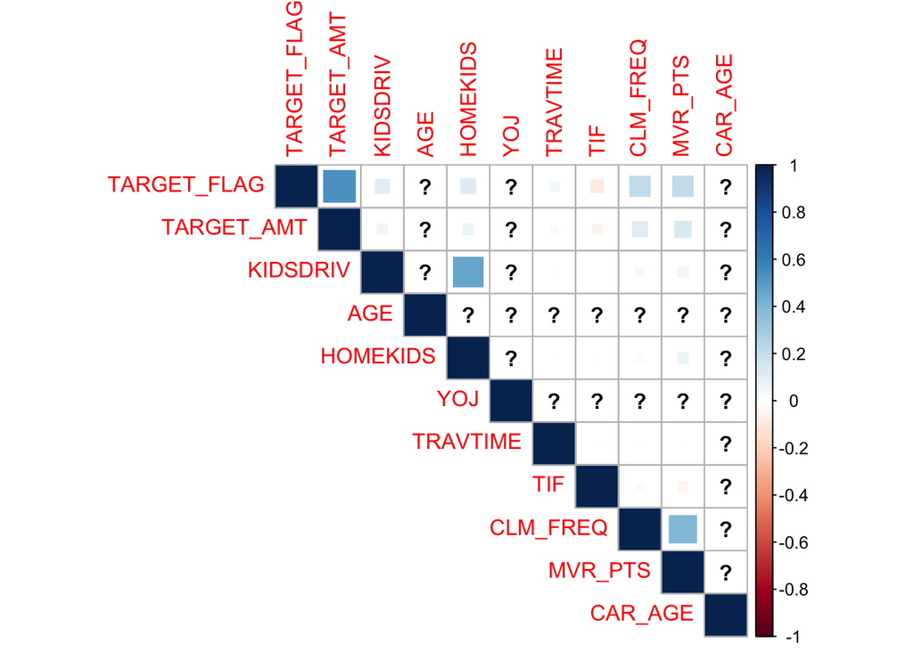

```r
#TARGET_AMT,KIDSDRIV,AGE,YOJ,TRAVTIME,TIF,CLM_FREQ,MVR_PTS,CAR_AGE, INCOME,HOME_VAL,BLUEBOOK,OLDCLAIM



cordata = cor(ggtrain$continuous)
corrplot(cordata, method = "square", type = "upper")
```

From the corrplot we can see that KIDSDRIV and HOMEKIDS has a litte positive correlation.

With respect to response and predictor variables, We do not see much of a bigger correlation.

*Missing Value*

On anlysis of missing values, we see CAR_AGE, YOJ and AGE has missing values in the respective order.

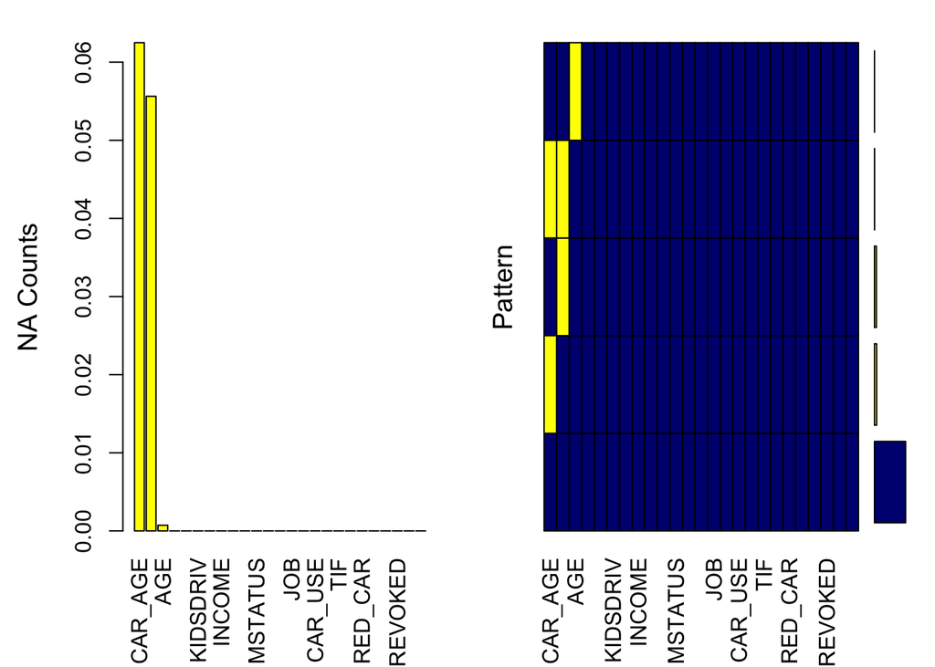

```
##
##  Variables sorted by number of missings:
##     Variable       Count
##      CAR_AGE 0.062492342
##          YOJ 0.055630437
##          AGE 0.000735204
##  TARGET_FLAG 0.000000000
##   TARGET_AMT 0.000000000
##     KIDSDRIV 0.000000000
##     HOMEKIDS 0.000000000
##       INCOME 0.000000000
##      PARENT1 0.000000000
##     HOME_VAL 0.000000000
##      MSTATUS 0.000000000
##          SEX 0.000000000
##    EDUCATION 0.000000000
##          JOB 0.000000000
##     TRAVTIME 0.000000000
##      CAR_USE 0.000000000
##     BLUEBOOK 0.000000000
##          TIF 0.000000000
##     CAR_TYPE 0.000000000
##      RED_CAR 0.000000000
##     OLDCLAIM 0.000000000
##     CLM_FREQ 0.000000000
##      REVOKED 0.000000000
##      MVR_PTS 0.000000000
##   URBANICITY 0.000000000
```

```r
VIM::aggr(train, col=c('navyblue','yellow'),
                      numbers=TRUE, sortVars=TRUE,
                       labels=names(train),
                       ylab=c("NA Counts","Pattern"))
```

## 2.DATA PREPARATION

From our visual exploration we have identified few variables to go through transformation based on the dataset.

1. We will make Home Kids as a Boolean instead of Factor.
2. Will reset the -ve values of CAR_AGE to 0.
3. We will change the Jobs and Education Levels.
4. For the variables CAR_AGE, AGE, YOJ we fill those missing values with Median/Mean.

We tried executing imputing these random missing values using MICE package.

But running the package lead to crashing of R server multiple times. So for this project dropped from using mice.

```r
train$HOMEKIDS[train$HOMEKIDS != 0 ] = 1

train$CAR_AGE[train$CAR_AGE < 0 ] = 0

train$JOB = as.character(train$JOB)
train$JOB[train$JOB == ""] = "Miscellaneous"
train$JOB <- as.factor(train$JOB)

train$EDUCATION <- ifelse(train$EDUCATION %in% c("PhD", "Masters"), 0, 1)


# ## Trying to use Mice package to fill in the missing values****
# mice_train =  mice(train, m = 1, maxit = 1, print = FALSE)
# train <- complete(mice_train)
#
#
# ###################


m = mean(train$AGE, na.rm = T)
train$AGE[is.na(train$AGE)] <- m

m = median(train$CAR_AGE, na.rm = T)
train$CAR_AGE[is.na(train$CAR_AGE)] <- m

m = mean(train$YOJ, na.rm = T)
train$YOJ[is.na(train$YOJ)] <- m

train$INCOME = as.numeric(train$INCOME)
train$HOME_VAL= as.numeric(train$HOME_VAL)
train$BLUEBOOK = as.numeric(train$BLUEBOOK)
train$OLDCLAIM= as.numeric(train$OLDCLAIM)

############## Transformation of Test Data#####################
test$HOMEKIDS[test$HOMEKIDS != 0 ] = 1
test$CAR_AGE[test$CAR_AGE < 0 ] = 0

test$JOB = as.character(test$JOB)
test$JOB[test$JOB == ""] = "Miscellaneous"
test$JOB <- as.factor(test$JOB)

test$EDUCATION <- ifelse(test$EDUCATION %in% c("PhD", "Masters"), 0, 1)

m = mean(test$AGE, na.rm = T)
test$AGE[is.na(test$AGE)] <- m

m = median(test$CAR_AGE, na.rm = T)
test$CAR_AGE[is.na(test$CAR_AGE)] <- m

m = mean(test$YOJ, na.rm = T)
test$YOJ[is.na(test$YOJ)] <- m

test$INCOME = as.numeric(test$INCOME)
test$HOME_VAL= as.numeric(test$HOME_VAL)
test$BLUEBOOK = as.numeric(test$BLUEBOOK)
test$OLDCLAIM= as.numeric(test$OLDCLAIM)
```

We will plot and see the missing elements.

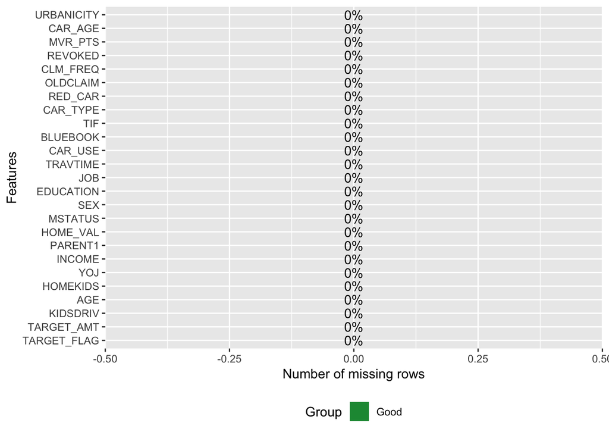

```r
plot_missing(train)
```

## 3. BUILDING MODELS

### Classification:

As approach we are going to build the following models.

Each of our logistic regression models will use bionomial regression with a logit link function

*Base Model and Transformed Variables*

1. The first model will be Base Model. It will contain all transformed data. It contains all the 24 variables(excluding TARGET_AMT)

```r
base_transform_model = glm(TARGET_FLAG ~ . -TARGET_AMT , family = binomial(link = 'logit'), data = train)

summary(base_transform_model)
```

```
##
## Call:
## glm(formula = TARGET_FLAG ~ . - TARGET_AMT, family = binomial(link = "logit"),
##     data = train)
##
## Deviance Residuals:
##     Min       1Q   Median       3Q      Max
## -2.5221  -0.7269  -0.4069   0.6513   3.1181
##
## Coefficients:
##                                   Estimate Std. Error z value Pr(>|z|)
## (Intercept)                     -9.866e-01  3.062e-01  -3.222 0.001273 **
## KIDSDRIV                         3.485e-01  5.945e-02   5.862 4.59e-09 ***
## AGE                             -8.537e-04  4.058e-03  -0.210 0.833383
## HOMEKIDS                         3.039e-01  9.644e-02   3.151 0.001626 **
## YOJ                             -1.917e-02  8.620e-03  -2.223 0.026190 *
## INCOME                          -1.639e-05  1.581e-05  -1.037 0.299720
## PARENT1Yes                       2.237e-01  1.198e-01   1.867 0.061945 .
## HOME_VAL                        -9.019e-05  2.011e-05  -4.485 7.30e-06 ***
## MSTATUSz_No                      5.555e-01  8.036e-02   6.913 4.74e-12 ***
## SEXz_F                          -2.961e-01  1.027e-01  -2.882 0.003952 **
## EDUCATION                        1.582e-02  1.330e-01   0.119 0.905315
## JOBDoctor                       -1.143e+00  2.570e-01  -4.446 8.76e-06 ***
## JOBHome Maker                   -5.448e-02  1.407e-01  -0.387 0.698632
## JOBLawyer                       -5.424e-01  1.791e-01  -3.029 0.002454 **
## JOBManager                      -1.246e+00  1.368e-01  -9.107  < 2e-16 ***
## JOBMiscellaneous                -7.007e-01  1.903e-01  -3.683 0.000231 ***
## JOBProfessional                 -5.218e-01  1.159e-01  -4.501 6.75e-06 ***
## JOBStudent                      -5.956e-02  1.280e-01  -0.465 0.641702
## JOBz_Blue Collar                -1.753e-01  1.060e-01  -1.654 0.098196 .
## TRAVTIME                         1.437e-02  1.872e-03   7.675 1.65e-14 ***
## CAR_USEPrivate                  -7.015e-01  8.655e-02  -8.105 5.29e-16 ***
## BLUEBOOK                         1.791e-05  3.358e-05   0.534 0.593654
## TIF                             -5.468e-02  7.297e-03  -7.493 6.71e-14 ***
## CAR_TYPEPanel Truck              2.149e-01  1.417e-01   1.517 0.129311
## CAR_TYPEPickup                   6.258e-01  1.011e-01   6.192 5.95e-10 ***
## CAR_TYPESports Car               1.224e+00  1.221e-01  10.023  < 2e-16 ***
## CAR_TYPEVan                      4.497e-01  1.205e-01   3.733 0.000190 ***
## CAR_TYPEz_SUV                    9.653e-01  1.027e-01   9.399  < 2e-16 ***
## RED_CARyes                       5.518e-03  8.596e-02   0.064 0.948817
## OLDCLAIM                         8.896e-05  4.232e-05   2.102 0.035548 *
## CLM_FREQ                         1.155e-01  3.201e-02   3.607 0.000310 ***
## REVOKEDYes                       7.451e-01  8.015e-02   9.296  < 2e-16 ***
## MVR_PTS                          1.060e-01  1.364e-02   7.774 7.61e-15 ***
## CAR_AGE                         -1.587e-02  6.867e-03  -2.312 0.020797 *
## URBANICITYz_Highly Rural/ Rural -2.338e+00  1.120e-01 -20.864  < 2e-16 ***
## ---
## Signif. codes:  0 '***' 0.001 '**' 0.01 '*' 0.05 '.' 0.1 ' ' 1
##
## (Dispersion parameter for binomial family taken to be 1)
##
##     Null deviance: 9418.0  on 8160  degrees of freedom
## Residual deviance: 7370.3  on 8126  degrees of freedom
## AIC: 7440.3
##
## Number of Fisher Scoring iterations: 5
```

```r
knitr::kable(vif(base_transform_model))
```

|  | GVIF | Df | GVIF^(1/(2*Df)) |
| --- | --- | --- | --- |
| KIDSDRIV | 1.298221 | 1 | 1.139395 |
| AGE | 1.516209 | 1 | 1.231344 |
| HOMEKIDS | 2.671089 | 1 | 1.634347 |
| YOJ | 1.474231 | 1 | 1.214179 |
| INCOME | 1.266935 | 1 | 1.125582 |
| PARENT1 | 2.350983 | 1 | 1.533292 |
| HOME_VAL | 1.309729 | 1 | 1.144434 |
| MSTATUS | 1.922674 | 1 | 1.386605 |
| SEX | 3.147536 | 1 | 1.774130 |
| EDUCATION | 4.059590 | 1 | 2.014842 |
| JOB | 12.381173 | 8 | 1.170301 |
| TRAVTIME | 1.036810 | 1 | 1.018239 |
| CAR_USE | 2.206358 | 1 | 1.485382 |
| BLUEBOOK | 1.121108 | 1 | 1.058824 |
| TIF | 1.010228 | 1 | 1.005101 |
| CAR_TYPE | 3.923111 | 5 | 1.146471 |
| RED_CAR | 1.836787 | 1 | 1.355281 |
| OLDCLAIM | 1.840900 | 1 | 1.356798 |
| CLM_FREQ | 1.850374 | 1 | 1.360285 |
| REVOKED | 1.016112 | 1 | 1.008024 |
| MVR_PTS | 1.183336 | 1 | 1.087813 |
| CAR_AGE | 1.672388 | 1 | 1.293209 |
| URBANICITY | 1.137012 | 1 | 1.066307 |

```r
hoslem.test(train$TARGET_FLAG, fitted(base_transform_model))
```

```
##
##  Hosmer and Lemeshow goodness of fit (GOF) test
##
## data:  train$TARGET_FLAG, fitted(base_transform_model)
## X-squared = 5.5714, df = 8, p-value = 0.6951
```

```r
rocBaseTransformPlot = roc(base_transform_model$y, fitted(base_transform_model))
AUC = as.numeric(pROC::roc(base_transform_model$y, fitted(base_transform_model))$auc)
AUC
```

```
## [1] 0.8088218
```

*Observations*

From the VIF function we can see 2 variables has VIF > 4. So this multicollinearity issue needs to be fixed. These can be removed from our model in future models.

Considering the hoslem test result this model is creating, this will not be the ideal candidate.

*Base Model Transformation pls Backward Elimination*

The following variables have been removed from base_model variables.

```r
train_new = subset(train, select = -c(AGE, INCOME, EDUCATION, JOB, CAR_TYPE))

base_backward_model = glm(TARGET_FLAG ~ . -TARGET_AMT , family = binomial(link = 'logit'), data = train_new)


summary(base_backward_model)
```

```
##
## Call:
## glm(formula = TARGET_FLAG ~ . - TARGET_AMT, family = binomial(link = "logit"),
##     data = train_new)
##
## Deviance Residuals:
##     Min       1Q   Median       3Q      Max
## -2.3355  -0.7434  -0.4461   0.7224   2.9736
##
## Coefficients:
##                                   Estimate Std. Error z value Pr(>|z|)
## (Intercept)                     -7.205e-01  1.549e-01  -4.653 3.27e-06 ***
## KIDSDRIV                         3.019e-01  5.700e-02   5.297 1.18e-07 ***
## HOMEKIDS                         4.008e-01  8.466e-02   4.735 2.19e-06 ***
## YOJ                             -4.022e-02  7.219e-03  -5.572 2.51e-08 ***
## PARENT1Yes                       1.993e-01  1.171e-01   1.702 0.088821 .
## HOME_VAL                        -1.379e-04  1.899e-05  -7.262 3.82e-13 ***
## MSTATUSz_No                      4.203e-01  7.766e-02   5.412 6.24e-08 ***
## SEXz_F                           2.683e-01  7.927e-02   3.385 0.000712 ***
## TRAVTIME                         1.476e-02  1.830e-03   8.066 7.28e-16 ***
## CAR_USEPrivate                  -7.550e-01  6.049e-02 -12.480  < 2e-16 ***
## BLUEBOOK                         7.733e-05  3.173e-05   2.437 0.014795 *
## TIF                             -5.141e-02  7.144e-03  -7.197 6.15e-13 ***
## RED_CARyes                      -1.136e-02  8.397e-02  -0.135 0.892424
## OLDCLAIM                         9.868e-05  4.152e-05   2.377 0.017452 *
## CLM_FREQ                         1.239e-01  3.130e-02   3.958 7.55e-05 ***
## REVOKEDYes                       7.701e-01  7.796e-02   9.878  < 2e-16 ***
## MVR_PTS                          1.127e-01  1.337e-02   8.426  < 2e-16 ***
## CAR_AGE                         -4.352e-02  5.403e-03  -8.056 7.88e-16 ***
## URBANICITYz_Highly Rural/ Rural -2.103e+00  1.102e-01 -19.087  < 2e-16 ***
## ---
## Signif. codes:  0 '***' 0.001 '**' 0.01 '*' 0.05 '.' 0.1 ' ' 1
##
## (Dispersion parameter for binomial family taken to be 1)
##
##     Null deviance: 9418.0  on 8160  degrees of freedom
## Residual deviance: 7646.7  on 8142  degrees of freedom
## AIC: 7684.7
##
## Number of Fisher Scoring iterations: 5
```

```r
knitr::kable(vif(base_backward_model))
```

|  | x |
| --- | --- |
| KIDSDRIV | 1.242013 |
| HOMEKIDS | 2.144087 |
| YOJ | 1.051585 |
| PARENT1 | 2.359908 |
| HOME_VAL | 1.212542 |
| MSTATUS | 1.874480 |
| SEX | 1.952126 |
| TRAVTIME | 1.032653 |
| CAR_USE | 1.122006 |
| BLUEBOOK | 1.012350 |
| TIF | 1.005389 |
| RED_CAR | 1.818887 |
| OLDCLAIM | 1.844528 |
| CLM_FREQ | 1.854404 |
| REVOKED | 1.013313 |
| MVR_PTS | 1.179388 |
| CAR_AGE | 1.071260 |
| URBANICITY | 1.103281 |

```r
hoslem.test(train$TARGET_FLAG, fitted(base_backward_model))
```

```
##
##  Hosmer and Lemeshow goodness of fit (GOF) test
##
## data:  train$TARGET_FLAG, fitted(base_backward_model)
## X-squared = 9.9022, df = 8, p-value = 0.272
```

```r
rocBaseBackwardPlot = roc(base_backward_model$y, fitted(base_backward_model))
AUC = as.numeric(pROC::roc(base_backward_model$y, fitted(base_backward_model))$auc)
AUC
```

```
## [1] 0.7875901
```

*Observations*

From the VIF function we can see 0 variables has VIF > 4.

*Step Model*

3. For our final model, we will use the step function on the base model and transformation variables.

```r
base_step_model = step(base_transform_model)
```

```
## Start:  AIC=7440.31
## TARGET_FLAG ~ (TARGET_AMT + KIDSDRIV + AGE + HOMEKIDS + YOJ +
##     INCOME + PARENT1 + HOME_VAL + MSTATUS + SEX + EDUCATION +
##     JOB + TRAVTIME + CAR_USE + BLUEBOOK + TIF + CAR_TYPE + RED_CAR +
##     OLDCLAIM + CLM_FREQ + REVOKED + MVR_PTS + CAR_AGE + URBANICITY) -
##     TARGET_AMT
##
##              Df Deviance    AIC
## - RED_CAR     1   7370.3 7438.3
## - EDUCATION   1   7370.3 7438.3
## - AGE         1   7370.4 7438.4
## - BLUEBOOK    1   7370.6 7438.6
## - INCOME      1   7371.4 7439.4
## <none>            7370.3 7440.3
## - PARENT1     1   7373.8 7441.8
## - OLDCLAIM    1   7374.7 7442.7
## - YOJ         1   7375.2 7443.2
## - CAR_AGE     1   7375.6 7443.6
## - SEX         1   7378.6 7446.6
## - HOMEKIDS    1   7380.2 7448.2
## - CLM_FREQ    1   7383.2 7451.2
## - HOME_VAL    1   7390.6 7458.6
## - KIDSDRIV    1   7404.6 7472.6
## - MSTATUS     1   7418.2 7486.2
## - TIF         1   7428.5 7496.5
## - TRAVTIME    1   7429.4 7497.4
## - MVR_PTS     1   7431.2 7499.2
## - CAR_USE     1   7437.1 7505.1
## - REVOKED     1   7455.3 7523.3
## - JOB         8   7487.1 7541.1
## - CAR_TYPE    5   7501.0 7561.0
## - URBANICITY  1   7994.6 8062.6
##
## Step:  AIC=7438.31
## TARGET_FLAG ~ KIDSDRIV + AGE + HOMEKIDS + YOJ + INCOME + PARENT1 +
##     HOME_VAL + MSTATUS + SEX + EDUCATION + JOB + TRAVTIME + CAR_USE +
##     BLUEBOOK + TIF + CAR_TYPE + OLDCLAIM + CLM_FREQ + REVOKED +
##     MVR_PTS + CAR_AGE + URBANICITY
##
##              Df Deviance    AIC
```

[output cut: 121 more lines]

```
## - YOJ         1   7378.3 7436.3
## - SEX         1   7383.2 7441.2
## - CLM_FREQ    1   7384.5 7442.5
## - HOMEKIDS    1   7384.9 7442.9
## - HOME_VAL    1   7391.9 7449.9
## - KIDSDRIV    1   7407.2 7465.2
## - MSTATUS     1   7420.5 7478.5
## - TIF         1   7430.2 7488.2
## - TRAVTIME    1   7430.8 7488.8
## - MVR_PTS     1   7432.4 7490.4
## - CAR_USE     1   7438.2 7496.2
## - REVOKED     1   7457.0 7515.0
## - JOB         8   7509.3 7553.3
## - CAR_TYPE    5   7506.8 7556.8
## - URBANICITY  1   7997.1 8055.1
```

```r
summary(base_step_model)
```

```
##
## Call:
## glm(formula = TARGET_FLAG ~ KIDSDRIV + HOMEKIDS + YOJ + PARENT1 +
##     HOME_VAL + MSTATUS + SEX + JOB + TRAVTIME + CAR_USE + TIF +
##     CAR_TYPE + OLDCLAIM + CLM_FREQ + REVOKED + MVR_PTS + CAR_AGE +
##     URBANICITY, family = binomial(link = "logit"), data = train)
##
## Deviance Residuals:
##     Min       1Q   Median       3Q      Max
## -2.5258  -0.7270  -0.4063   0.6525   3.1130
##
## Coefficients:
##                                   Estimate Std. Error z value Pr(>|z|)
## (Intercept)                     -1.007e+00  1.882e-01  -5.353 8.64e-08 ***
## KIDSDRIV                         3.472e-01  5.831e-02   5.954 2.62e-09 ***
## HOMEKIDS                         3.155e-01  8.694e-02   3.630 0.000284 ***
## YOJ                             -2.120e-02  8.331e-03  -2.544 0.010947 *
## PARENT1Yes                       2.225e-01  1.197e-01   1.858 0.063112 .
## HOME_VAL                        -8.995e-05  2.014e-05  -4.466 7.95e-06 ***
## MSTATUSz_No                      5.576e-01  7.995e-02   6.974 3.08e-12 ***
## SEXz_F                          -2.986e-01  8.887e-02  -3.360 0.000780 ***
## JOBDoctor                       -1.155e+00  2.302e-01  -5.019 5.20e-07 ***
## JOBHome Maker                   -4.573e-02  1.378e-01  -0.332 0.740007
## JOBLawyer                       -5.744e-01  1.374e-01  -4.180 2.92e-05 ***
## JOBManager                      -1.268e+00  1.288e-01  -9.847  < 2e-16 ***
## JOBMiscellaneous                -7.210e-01  1.537e-01  -4.691 2.72e-06 ***
## JOBProfessional                 -5.476e-01  1.131e-01  -4.841 1.29e-06 ***
## JOBStudent                      -4.577e-02  1.272e-01  -0.360 0.719035
## JOBz_Blue Collar                -1.940e-01  1.047e-01  -1.852 0.063969 .
## TRAVTIME                         1.436e-02  1.871e-03   7.672 1.69e-14 ***
## CAR_USEPrivate                  -6.991e-01  8.649e-02  -8.082 6.35e-16 ***
## TIF                             -5.477e-02  7.293e-03  -7.510 5.92e-14 ***
## CAR_TYPEPanel Truck              2.322e-01  1.390e-01   1.671 0.094763 .
## CAR_TYPEPickup                   6.398e-01  9.865e-02   6.486 8.82e-11 ***
## CAR_TYPESports Car               1.231e+00  1.209e-01  10.186  < 2e-16 ***
## CAR_TYPEVan                      4.546e-01  1.204e-01   3.776 0.000159 ***
## CAR_TYPEz_SUV                    9.692e-01  1.022e-01   9.488  < 2e-16 ***
## OLDCLAIM                         8.957e-05  4.230e-05   2.118 0.034197 *
## CLM_FREQ                         1.145e-01  3.198e-02   3.581 0.000343 ***
## REVOKEDYes                       7.458e-01  8.013e-02   9.307  < 2e-16 ***
## MVR_PTS                          1.056e-01  1.362e-02   7.755 8.85e-15 ***
## CAR_AGE                         -1.626e-02  6.479e-03  -2.509 0.012103 *
## URBANICITYz_Highly Rural/ Rural -2.338e+00  1.120e-01 -20.874  < 2e-16 ***
## ---
## Signif. codes:  0 '***' 0.001 '**' 0.01 '*' 0.05 '.' 0.1 ' ' 1
##
## (Dispersion parameter for binomial family taken to be 1)
##
##     Null deviance: 9418.0  on 8160  degrees of freedom
## Residual deviance: 7371.8  on 8131  degrees of freedom
## AIC: 7431.8
##
## Number of Fisher Scoring iterations: 5
```

```r
knitr::kable(vif(base_step_model))
```

|  | GVIF | Df | GVIF^(1/(2*Df)) |
| --- | --- | --- | --- |
| KIDSDRIV | 1.249841 | 1 | 1.117963 |
| HOMEKIDS | 2.171342 | 1 | 1.473547 |
| YOJ | 1.377388 | 1 | 1.173622 |
| PARENT1 | 2.347636 | 1 | 1.532200 |
| HOME_VAL | 1.309494 | 1 | 1.144331 |
| MSTATUS | 1.903822 | 1 | 1.379790 |
| SEX | 2.355548 | 1 | 1.534780 |
| JOB | 4.706122 | 8 | 1.101644 |
| TRAVTIME | 1.036521 | 1 | 1.018097 |
| CAR_USE | 2.203776 | 1 | 1.484512 |
| TIF | 1.009478 | 1 | 1.004728 |
| CAR_TYPE | 3.597385 | 5 | 1.136577 |
| OLDCLAIM | 1.839934 | 1 | 1.356442 |
| CLM_FREQ | 1.847465 | 1 | 1.359215 |
| REVOKED | 1.015661 | 1 | 1.007800 |
| MVR_PTS | 1.181072 | 1 | 1.086771 |
| CAR_AGE | 1.488861 | 1 | 1.220189 |
| URBANICITY | 1.136417 | 1 | 1.066029 |

```r
hoslem.test(train$TARGET_FLAG, fitted(base_step_model))
```

```
##
##  Hosmer and Lemeshow goodness of fit (GOF) test
##
## data:  train$TARGET_FLAG, fitted(base_step_model)
## X-squared = 4.1094, df = 8, p-value = 0.8471
```

```r
rocBaseStepPlot = roc(base_step_model$y, fitted(base_step_model))
AUC = as.numeric(pROC::roc(base_step_model$y, fitted(base_step_model))$auc)
AUC
```

```
## [1] 0.8087917
```

*Observations*

From the VIF function we can see that the following variables has VIF > 4. JOB is the only variable which has a little higher vIF.

### Regression Analysis.

*Base plus Transformed Variables.*

For Linear Regression, we will first do as Base Model with transformed variables.

```r
regbaseplustransform = lm(TARGET_AMT ~ .-TARGET_FLAG, data = train)
summary(regbaseplustransform)
```

```
##
## Call:
## lm(formula = TARGET_AMT ~ . - TARGET_FLAG, data = train)
##
## Residuals:
##    Min     1Q Median     3Q    Max
##  -5609  -1686   -766    344 103811
##
## Coefficients:
##                                   Estimate Std. Error t value Pr(>|t|)
## (Intercept)                      1.646e+03  5.299e+02   3.107 0.001895 **
## KIDSDRIV                         2.838e+02  1.113e+02   2.550 0.010801 *
## AGE                              9.591e+00  7.174e+00   1.337 0.181277
## HOMEKIDS                         3.319e+02  1.654e+02   2.007 0.044774 *
## YOJ                             -9.457e+00  1.521e+01  -0.622 0.534162
## INCOME                          -1.111e-02  2.677e-02  -0.415 0.678067
## PARENT1Yes                       4.684e+02  2.170e+02   2.158 0.030926 *
## HOME_VAL                        -7.358e-02  3.490e-02  -2.109 0.034999 *
## MSTATUSz_No                      5.710e+02  1.377e+02   4.147 3.41e-05 ***
## SEXz_F                          -2.987e+02  1.713e+02  -1.743 0.081357 .
## EDUCATION                       -2.512e+02  2.127e+02  -1.181 0.237634
## JOBDoctor                       -1.119e+03  3.858e+02  -2.900 0.003744 **
## JOBHome Maker                   -8.225e+01  2.464e+02  -0.334 0.738558
## JOBLawyer                       -4.800e+02  2.952e+02  -1.626 0.103983
## JOBManager                      -1.193e+03  2.256e+02  -5.286 1.28e-07 ***
## JOBMiscellaneous                -7.284e+02  3.323e+02  -2.192 0.028434 *
## JOBProfessional                 -2.515e+02  2.022e+02  -1.244 0.213601
## JOBStudent                      -1.767e+02  2.333e+02  -0.757 0.448855
## JOBz_Blue Collar                -7.443e+01  1.919e+02  -0.388 0.698070
## TRAVTIME                         1.192e+01  3.221e+00   3.701 0.000216 ***
## CAR_USEPrivate                  -7.385e+02  1.569e+02  -4.708 2.55e-06 ***
## BLUEBOOK                         2.008e-04  5.965e-02   0.003 0.997315
## TIF                             -4.774e+01  1.218e+01  -3.920 8.93e-05 ***
## CAR_TYPEPanel Truck              4.420e+02  2.520e+02   1.754 0.079432 .
## CAR_TYPEPickup                   3.763e+02  1.720e+02   2.188 0.028697 *
## CAR_TYPESports Car               9.240e+02  2.058e+02   4.491 7.20e-06 ***
## CAR_TYPEVan                      5.785e+02  2.068e+02   2.797 0.005175 **
## CAR_TYPEz_SUV                    6.669e+02  1.655e+02   4.029 5.65e-05 ***
## RED_CARyes                      -5.013e+01  1.490e+02  -0.336 0.736580
## OLDCLAIM                        -2.493e-02  8.366e-02  -0.298 0.765702
## CLM_FREQ                         1.192e+02  6.303e+01   1.892 0.058565 .
## REVOKEDYes                       4.391e+02  1.556e+02   2.821 0.004796 **
## MVR_PTS                          1.753e+02  2.615e+01   6.704 2.17e-11 ***
## CAR_AGE                         -3.481e+01  1.188e+01  -2.930 0.003395 **
## URBANICITYz_Highly Rural/ Rural -1.660e+03  1.399e+02 -11.867  < 2e-16 ***
## ---
## Signif. codes:  0 '***' 0.001 '**' 0.01 '*' 0.05 '.' 0.1 ' ' 1
##
## Residual standard error: 4546 on 8126 degrees of freedom
## Multiple R-squared:  0.06986,    Adjusted R-squared:  0.06597
## F-statistic: 17.95 on 34 and 8126 DF,  p-value: < 2.2e-16
```

*Observations* *

```r
BICBasePlusTransform = step(regbaseplustransform)
```

```
## Start:  AIC=137499.6
## TARGET_AMT ~ (TARGET_FLAG + KIDSDRIV + AGE + HOMEKIDS + YOJ +
##     INCOME + PARENT1 + HOME_VAL + MSTATUS + SEX + EDUCATION +
##     JOB + TRAVTIME + CAR_USE + BLUEBOOK + TIF + CAR_TYPE + RED_CAR +
##     OLDCLAIM + CLM_FREQ + REVOKED + MVR_PTS + CAR_AGE + URBANICITY) -
##     TARGET_FLAG
##
##              Df  Sum of Sq        RSS    AIC
## - BLUEBOOK    1        234 1.6795e+11 137498
## - OLDCLAIM    1    1835544 1.6795e+11 137498
## - RED_CAR     1    2338867 1.6795e+11 137498
## - INCOME      1    3561586 1.6795e+11 137498
## - YOJ         1    7988239 1.6796e+11 137498
## - EDUCATION   1   28827474 1.6798e+11 137499
## - AGE         1   36942849 1.6799e+11 137499
## <none>                     1.6795e+11 137500
## - SEX         1   62796709 1.6801e+11 137501
## - CLM_FREQ    1   73962009 1.6802e+11 137501
## - HOMEKIDS    1   83259125 1.6803e+11 137502
## - HOME_VAL    1   91905585 1.6804e+11 137502
## - PARENT1     1   96285923 1.6805e+11 137502
## - KIDSDRIV    1  134356783 1.6808e+11 137504
## - REVOKED     1  164504877 1.6811e+11 137506
## - CAR_AGE     1  177481567 1.6813e+11 137506
## - TRAVTIME    1  283082422 1.6823e+11 137511
## - TIF         1  317580679 1.6827e+11 137513
## - MSTATUS     1  355392690 1.6830e+11 137515
## - CAR_TYPE    5  566183808 1.6852e+11 137517
## - CAR_USE     1  458060492 1.6841e+11 137520
## - JOB         8  825911570 1.6877e+11 137524
## - MVR_PTS     1  928773611 1.6888e+11 137543
## - URBANICITY  1 2910765489 1.7086e+11 137638
##
## Step:  AIC=137497.6
## TARGET_AMT ~ KIDSDRIV + AGE + HOMEKIDS + YOJ + INCOME + PARENT1 +
##     HOME_VAL + MSTATUS + SEX + EDUCATION + JOB + TRAVTIME + CAR_USE +
##     TIF + CAR_TYPE + RED_CAR + OLDCLAIM + CLM_FREQ + REVOKED +
##     MVR_PTS + CAR_AGE + URBANICITY
##
##              Df  Sum of Sq        RSS    AIC
```

[output cut: 169 more lines]

```
## - SEX         1   71319769 1.6810e+11 137491
## - HOME_VAL    1   85132097 1.6812e+11 137492
## - PARENT1     1   97906975 1.6813e+11 137492
## - CLM_FREQ    1  100739436 1.6813e+11 137493
## - CAR_AGE     1  147680577 1.6818e+11 137495
## - REVOKED     1  167260491 1.6820e+11 137496
## - KIDSDRIV    1  170735073 1.6820e+11 137496
## - TRAVTIME    1  283139671 1.6832e+11 137501
## - TIF         1  314035565 1.6835e+11 137503
## - MSTATUS     1  353418972 1.6839e+11 137505
## - CAR_TYPE    5  598879597 1.6863e+11 137509
## - CAR_USE     1  459509327 1.6849e+11 137510
## - JOB         8  804605159 1.6884e+11 137513
## - MVR_PTS     1  927418649 1.6896e+11 137533
## - URBANICITY  1 2909345072 1.7094e+11 137628
```

```r
summary(BICBasePlusTransform)
```

```
##
## Call:
## lm(formula = TARGET_AMT ~ KIDSDRIV + HOMEKIDS + PARENT1 + HOME_VAL +
##     MSTATUS + SEX + JOB + TRAVTIME + CAR_USE + TIF + CAR_TYPE +
##     CLM_FREQ + REVOKED + MVR_PTS + CAR_AGE + URBANICITY, data = train)
##
## Residuals:
##    Min     1Q Median     3Q    Max
##  -5615  -1693   -766    338 103828
##
## Coefficients:
##                                   Estimate Std. Error t value Pr(>|t|)
## (Intercept)                      1.641e+03  2.864e+02   5.730 1.04e-08 ***
## KIDSDRIV                         3.147e+02  1.095e+02   2.875 0.004055 **
## HOMEKIDS                         2.241e+02  1.483e+02   1.511 0.130704
## PARENT1Yes                       4.720e+02  2.168e+02   2.177 0.029518 *
## HOME_VAL                        -7.068e-02  3.482e-02  -2.030 0.042399 *
## MSTATUSz_No                      5.633e+02  1.362e+02   4.136 3.57e-05 ***
## SEXz_F                          -2.720e+02  1.464e+02  -1.858 0.063213 .
## JOBDoctor                       -8.557e+02  3.423e+02  -2.500 0.012447 *
## JOBHome Maker                    4.011e+01  2.295e+02   0.175 0.861271
## JOBLawyer                       -2.414e+02  2.346e+02  -1.029 0.303462
## JOBManager                      -1.092e+03  2.124e+02  -5.144 2.75e-07 ***
## JOBMiscellaneous                -5.044e+02  2.822e+02  -1.787 0.073912 .
## JOBProfessional                 -2.205e+02  1.975e+02  -1.117 0.264233
## JOBStudent                      -1.195e+02  2.201e+02  -0.543 0.587082
## JOBz_Blue Collar                -8.050e+01  1.899e+02  -0.424 0.671617
## TRAVTIME                         1.192e+01  3.220e+00   3.702 0.000215 ***
## CAR_USEPrivate                  -7.393e+02  1.568e+02  -4.716 2.45e-06 ***
## TIF                             -4.746e+01  1.217e+01  -3.899 9.75e-05 ***
## CAR_TYPEPanel Truck              4.580e+02  2.471e+02   1.854 0.063803 .
## CAR_TYPEPickup                   3.784e+02  1.680e+02   2.252 0.024324 *
## CAR_TYPESports Car               9.461e+02  2.038e+02   4.643 3.48e-06 ***
## CAR_TYPEVan                      5.835e+02  2.065e+02   2.826 0.004724 **
## CAR_TYPEz_SUV                    6.754e+02  1.648e+02   4.100 4.18e-05 ***
## CLM_FREQ                         1.078e+02  4.881e+01   2.208 0.027262 *
## REVOKEDYes                       4.409e+02  1.549e+02   2.845 0.004448 **
## MVR_PTS                          1.728e+02  2.580e+01   6.700 2.22e-11 ***
## CAR_AGE                         -2.983e+01  1.116e+01  -2.674 0.007520 **
## URBANICITYz_Highly Rural/ Rural -1.653e+03  1.393e+02 -11.867  < 2e-16 ***
## ---
## Signif. codes:  0 '***' 0.001 '**' 0.01 '*' 0.05 '.' 0.1 ' ' 1
##
## Residual standard error: 4545 on 8133 degrees of freedom
## Multiple R-squared:  0.0694, Adjusted R-squared:  0.06631
## F-statistic: 22.46 on 27 and 8133 DF,  p-value: < 2.2e-16
```

```r
results = NULL
modellist = list(m1 = regbaseplustransform, m2 = BICBasePlusTransform)

for(i in names(modellist)){
    s = summary(modellist[[i]])
    name = i
    mse <- mean(s$residuals^2)
    r2 <- s$r.squared
    f <- s$fstatistic[1]
    k <- s$fstatistic[2]
    n <- s$fstatistic[3]
    results = rbind(results, data.frame(
        name = name, rsquared = r2, mse = mse, f = f,
        k = k, n = n))
}
rownames(results) = NULL
results
```

```
##   name   rsquared      mse        f  k    n
## 1   m1 0.06986176 20579455 17.95105 34 8126
## 2   m2 0.06939632 20589753 22.46253 27 8133
```

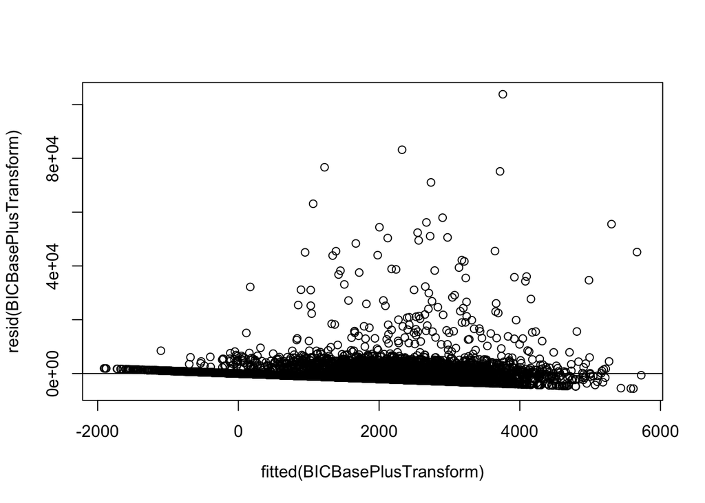

```r
###### Plots ######

plot(fitted(BICBasePlusTransform), resid(BICBasePlusTransform))
abline(h=0)
```

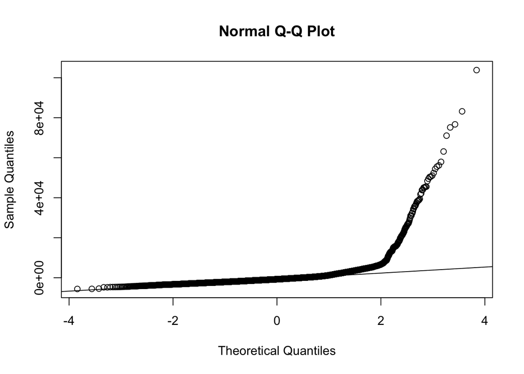

```r
qqnorm(BICBasePlusTransform$residuals)
qqline(BICBasePlusTransform$residuals)
```

Comparing the base model and BICplusbase model, all the values are near identical from the above table. But the QQ plot is not normal as expected with heavier tails.

## 4. MODEL SELECTION:

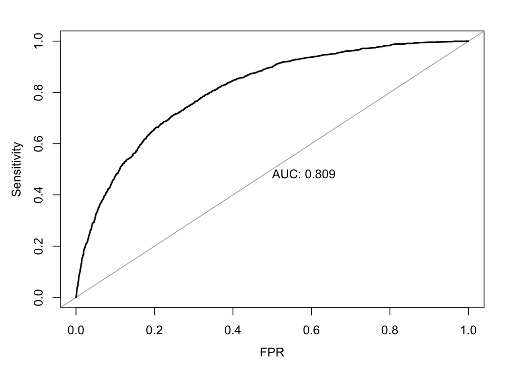

```r
#plot(rocBasePlot, asp=NA, legacy.axes = TRUE, print.auc=TRUE, xlab="FPR")
plot(rocBaseTransformPlot, asp=NA, legacy.axes = TRUE, print.auc=TRUE, xlab="FPR")
```

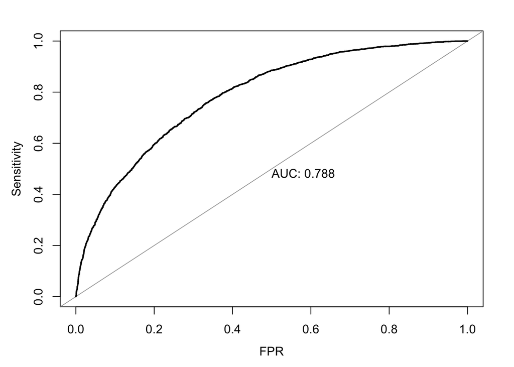

```r
plot(rocBaseBackwardPlot, asp=NA, legacy.axes = TRUE, print.auc=TRUE, xlab="FPR")
```

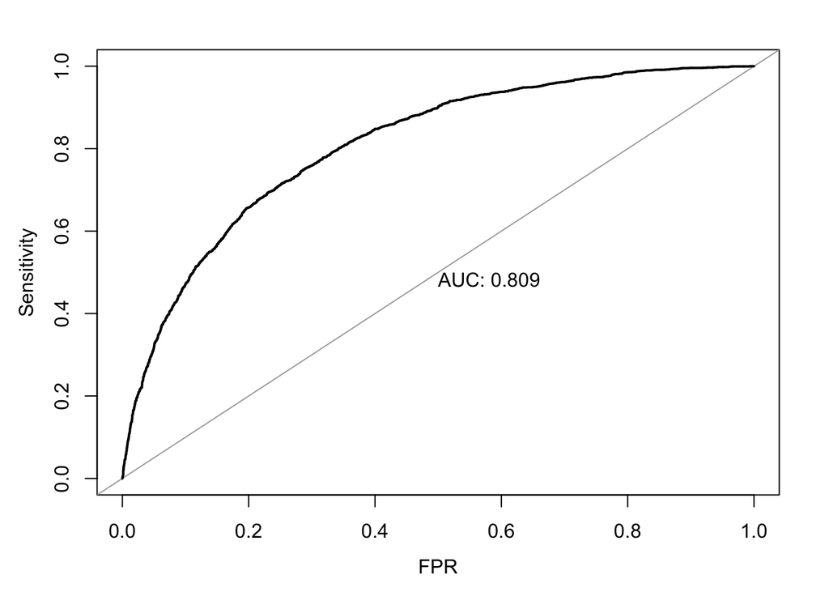

```r
plot(rocBaseStepPlot, asp=NA, legacy.axes = TRUE, print.auc=TRUE, xlab="FPR")
```

*confusion Matrix.*

```r
# Confusion Matrix of Base Transformation Model
baseTransformConfusion = as.factor(as.integer(fitted(base_transform_model ) > .5))
baseTransformCM = confusionMatrix(baseTransformConfusion, as.factor(base_transform_model$y), positive = "1")
caretTransformResults = data.frame(Accurarcy = baseTransformCM$overall[['Accuracy']],
                           ClassErrorRate = 1 - baseTransformCM$overall[['Accuracy']],
                           Precision = baseTransformCM$byClass[['Precision']],
                           Senstivity = baseTransformCM$byClass[['Sensitivity']],
                           Specificity = baseTransformCM$byClass[['Specificity']],
                           F1 = baseTransformCM$byClass[['F1']])

# Confusion Matrix of Base Backward Elimination Model
baseBackwardConfusion = as.factor(as.integer(fitted(base_backward_model ) > .5))
baseBackwardCM = confusionMatrix(baseBackwardConfusion, as.factor(base_backward_model$y), positive = "1")
caretBackwardResults = data.frame(Accurarcy = baseBackwardCM$overall[['Accuracy']],
                           ClassErrorRate = 1 - baseBackwardCM$overall[['Accuracy']],
                           Precision = baseBackwardCM$byClass[['Precision']],
                           Senstivity = baseBackwardCM$byClass[['Sensitivity']],
                           Specificity = baseBackwardCM$byClass[['Specificity']],
                           F1 = baseBackwardCM$byClass[['F1']])

# Confusion Matrix of Base Step Model
baseStepConfusion = as.factor(as.integer(fitted(base_step_model ) > .5))
baseStepCM = confusionMatrix(baseStepConfusion, as.factor(base_step_model$y), positive = "1")
caretStepResults = data.frame(Accurarcy = baseStepCM$overall[['Accuracy']],
                           ClassErrorRate = 1 - baseStepCM$overall[['Accuracy']],
                           Precision = baseStepCM$byClass[['Precision']],
                           Senstivity = baseStepCM$byClass[['Sensitivity']],
                           Specificity = baseStepCM$byClass[['Specificity']],
                           F1 = baseStepCM$byClass[['F1']])
TotalConMatrix = rbind(caretTransformResults, caretBackwardResults, caretStepResults)
knitr::kable(TotalConMatrix)
```

| Accurarcy | ClassErrorRate | Precision | Senstivity | Specificity | F1 |
| --- | --- | --- | --- | --- | --- |
| 0.7872810 | 0.2127190 | 0.6545589 | 0.4101254 | 0.9224368 | 0.5042833 |
| 0.7789487 | 0.2210513 | 0.6438582 | 0.3627497 | 0.9280959 | 0.4640523 |
| 0.7869134 | 0.2130866 | 0.6528804 | 0.4105899 | 0.9217710 | 0.5041346 |

Since all the values are almost identical for all the models we will use Base_Step_Model for our prediction.

## Evalution

```r
eval_results = predict(base_step_model, newdata = test)
table(as.integer(eval_results > .5))
```

```
##
##    0    1
## 1936  205
```

```r
eval_amount = predict(BICBasePlusTransform, test)
```

## References

https://www.analyticsvidhya.com/blog/2016/03/tutorial-powerful-packages-imputing-missing-values/